# Moodle Tasks

От централна гранична теорема (ЦГТ), ако $X_i$ еднакво разпределени, независими и с **крайна дисперсия** за $i = 1, ..., n$, то при увеличаване на обема на извадката
$$\frac{X_1 + X_2 + ... + X_n - n E[X]}{\sqrt{n D[X]}} \mathop{\to}^d N(0, 1)$$
В случая
$$E[X_i] = \frac{\frac{5}{2}}{\frac{1}{2}} = 5, \quad D[X_i] = \frac{\frac{5}{2}}{\left(\frac{1}{2}\right)^2} = 10$$
$$Y = X_1 + X_2 + ... + X_n$$
$$\frac{Y - 5n}{\sqrt{10n}} \mathop{\to}^d N(0, 1)$$

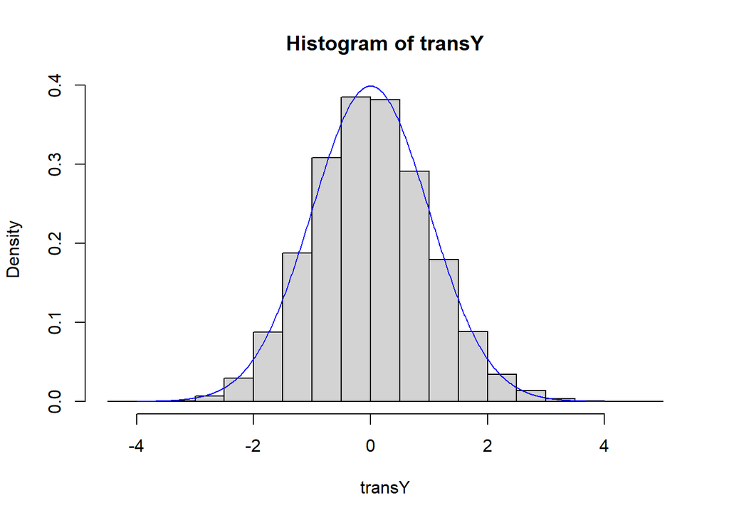

```r
> transY <- (y - 5*n) / sqrt(10*n)
> hist(transY, probability = TRUE)
> xCoord <- seq(-4, 4, 0.01)
> lines(xCoord, dnorm(xCoord, 0, 1), col = "blue")
```

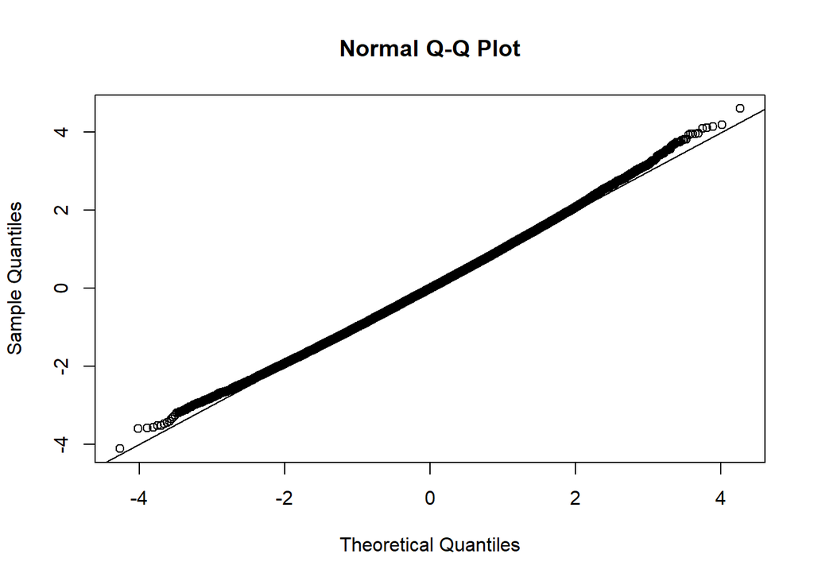

```r
> qqnorm(transY)
> qqline(transY)
```

е) $X_1, X_2, ..., X_n \in t(5)$

$$E[X_1 + X_2 + \ldots + X_n] = nE[X_1] = n 0 = 0$$

$$D[X_1 + X_2 + \ldots + X_n] = nD[X_1] = n \frac{5}{5 - 2} = \frac{5}{3}n$$

При $n = 2$
$$Y = X_1 + X_2$$
$$E[X_1 + X_2] = 2 E[X_1] = 2 * 0 = 0$$
$$D[X_1 + X_2] = 2 D[X_1] = 2 \frac{5}{3} = \frac{10}{3} \approx 3.33$$

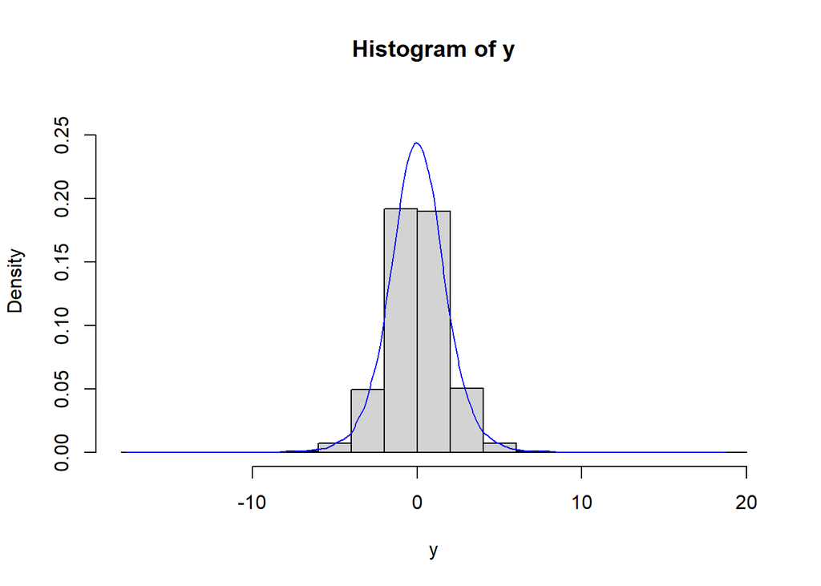

```r
> x1 <- rt(50000, df = 5)
> x2 <- rt(50000, df = 5)
> y <- x1 + x2
> mean(y)
[1] -0.001023507
> var(y)
[1] 3.364003
> hist(y, probability = TRUE, ylim = c(0,0.27))
> lines(density(y, bw = "SJ"), col = "blue")
```

При $n = 10$
$$Y = X_1 + X_2 + \ldots + X_{10}$$
$$E[X_1 + X_2 + \ldots + X_{10}] = 10 E[X_1] = 10 * 0 = 0$$
$$D[X_1 + X_2 + \ldots + X_{10}] = 10 D[X_1] = 10 \frac{5}{3} = \frac{50}{3} \approx 16.67$$

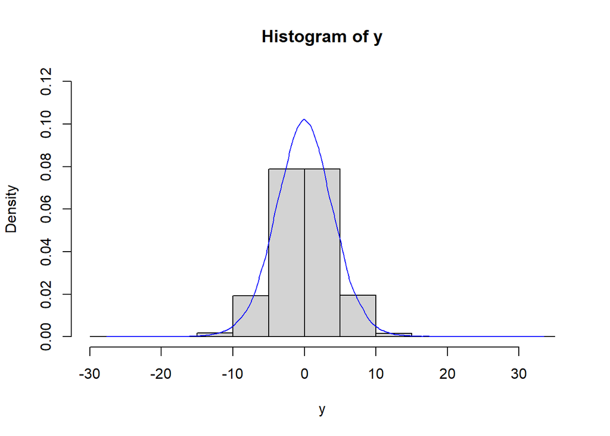

```r
> y <- 0
> for(i in 1:(10^5)){
+   y[i] <- sum(rt(10, df = 5))
+ }
> mean(y)
[1] 0.007812442
> var(y)
[1] 16.77315
> hist(y, probability = TRUE, ylim = c(0, 0.12))
> lines(density(y, bw = "SJ"), col = "blue")
```

При $n = 100$
$$Y = X_1 + X_2 + \ldots + X_{100}$$
$$E[X_1 + X_2 + \ldots + X_{100}] = 100 E[X_1] = 100 * 0 = 0$$
$$D[X_1 + X_2 + \ldots + X_{100}] = 100 D[X_1] = 100 \frac{5}{3} = \frac{500}{3} \approx 166.67$$

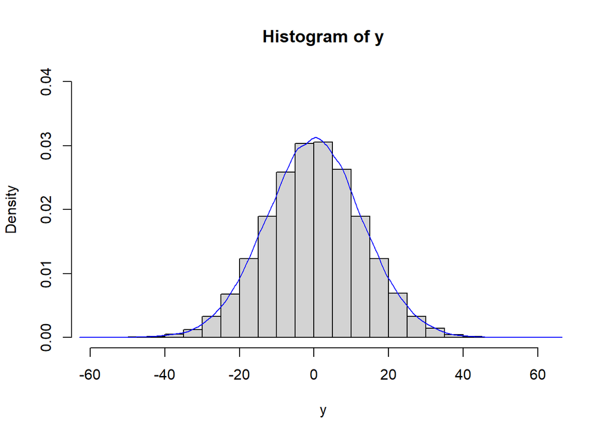

```r
> y <- 0
> for(i in 1:(10^5)){
+   y[i] <- sum(rt(100, df = 5))
+ }
> mean(y)
[1] 0.02618007
> var(y)
[1] 166.6741
> hist(y, probability = TRUE, ylim = c(0, 0.04))
> lines(density(y, bw = "SJ"), col = "blue")
```

т.к. $100$ е голямо можем да използваме централна гранична теорема (ЦГТ).

От централна гранична теорема (ЦГТ), ако $X_i$ еднакво разпределени, независими и с **крайна дисперсия** за $i = 1, ..., n$, то при увеличаване на обема на извадката
$$\frac{X_1 + X_2 + ... + X_n - n E[X]}{\sqrt{n D[X]}} \mathop{\to}^d N(0, 1)$$
В случая
$$E[X_i] = 0, \quad D[X_i] = \frac{5}{3}$$
$$Y = X_1 + X_2 + ... + X_n$$
$$\frac{Y - n E[X]}{\sqrt{n D[X]}} \mathop{\to}^d N(0, 1)$$
$$\frac{Y - 0n}{\sqrt{\frac{5}{3}n}} \mathop{\to}^d N(0, 1)$$

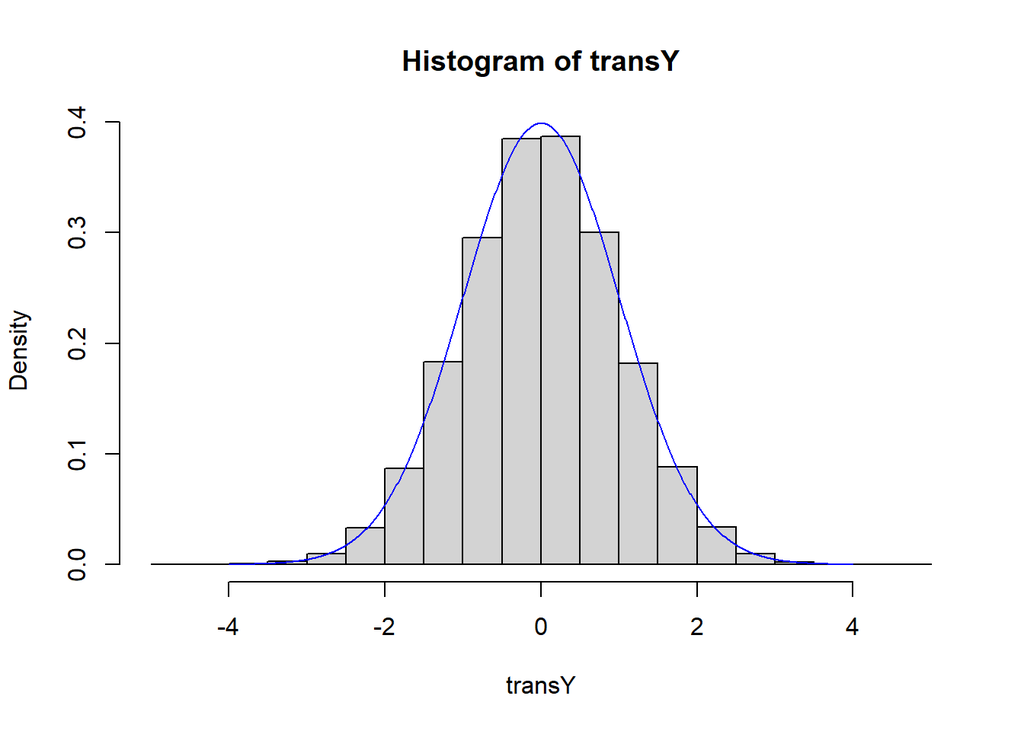

```r
> transY <- (y - 0*n) / sqrt((5*n)/3)
> hist(transY, probability = TRUE)
> xCoord <- seq(-4, 4, 0.01)
> lines(xCoord, dnorm(xCoord, 0, 1), col = "blue")
```

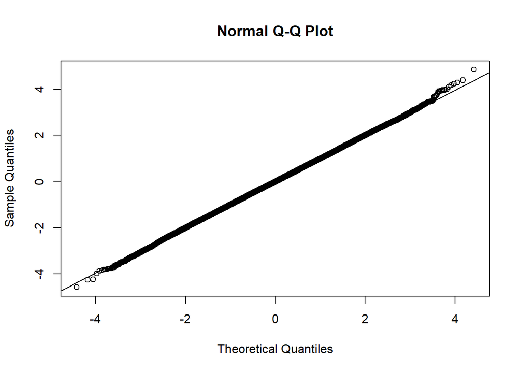

```r
> qqnorm(transY)
> qqline(transY)
```

ж) $X$ е смес от две разпределения $N(1, 2)$ и $N(5, 2)$ с вероятност за първото $p = 0.4$
$$I_A \in Bernoulli(0.4)$$
$$X = I_A * N(1, 2) + I_{\bar{A}} * N(5, 2)$$
$$X \stackrel{d}{=} X_1 \stackrel{d}{=} X_2 \stackrel{d}{=} ... \stackrel{d}{=} X_n$$
и тези случайни величини са независими

$$\begin{eqnarray}
E[X_1 + X_2 + \ldots + X_n]
&=& nE[X] = n(p * 1 + (1 - p) * 5) \\
&=& n(0.4 + (1 - 0.4) * 5) = 3.4n
\end{eqnarray}$$

$$\begin{eqnarray}
E[X_1^2] &=& E[[I_A N(1, 2) + I_{\bar{A}} N(5, 2)]^2]\\
&=& E[[I_A N(1, 2)]^2 + 2I_A N(1, 2) I_{\bar{A}} N(5, 2) + [I_{\bar{A}} N(5, 2)]^2]\\
&=& E[I_A [N(1, 2)]^2 + 2I_A N(1, 2) I_{\bar{A}} N(5, 2) + I_{\bar{A}} [N(5, 2)]^2]\\
&=& E[I_A] E[[N(1, 2)]^2] + 2E[0 * N(1, 2) N(5, 2)] + E[I_{\bar{A}}] E[[N(5, 2)]^2]\\
&=& E[I_A] E[[N(1, 2)]^2] + 2E[0] + E[I_{\bar{A}}] E[[N(5, 2)]^2]\\
&=& p (2 + 1^2) + 0 + (1 - p) (2 + 5^2)\\
&=& 3 p + 27(1 - p) = 27 - 24p = 27 - 24*0.4 = 17.4
\end{eqnarray}$$

$$DX_1 = E[X_1^2] - [EX_1]^2 = 17.4 - 3.4^2 = 5.842$$
$$D[X_1 + X_2 + \ldots + X_n] = nD[X_1] = 5.842n$$
При $n = 2$
$$Y = X_1 + X_2$$
$$E[X_1 + X_2] = 2 E[X_1] = 2 * 3.4 = 6.8$$
$$D[X_1 + X_2] = 2 D[X_1] = 2 * 5.842 = 11.684$$

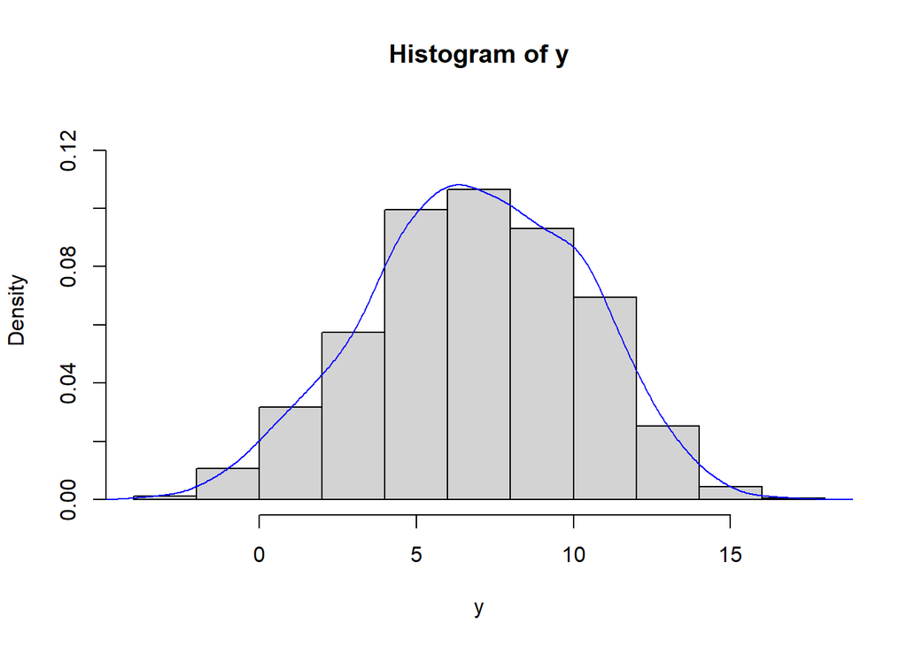

```r
> i <- rbinom(5000, size = 1, prob = 0.4)
> n1 <- rnorm(5000, mean = 1, sd = sqrt(2))
> n2 <- rnorm(5000, mean = 5, sd = sqrt(2))
> x1 <- i * n1 + (1 - i) * n2
> i <- rbinom(5000, size = 1, prob = 0.4)
> n1 <- rnorm(5000, mean = 1, sd = sqrt(2))
> n2 <- rnorm(5000, mean = 5, sd = sqrt(2))
> x2 <- i * n1 + (1 - i) * n2
> y <- x1 + x2
> mean(y)
[1] 6.866405
> var(y)
[1] 11.65165
> hist(y, probability = TRUE, ylim = c(0,0.13))
> lines(density(y, bw = "SJ"), col = "blue")
```

При $n = 10$
$$Y = X_1 + X_2 + \ldots + X_{10}$$
$$E[X_1 + X_2 + \ldots + X_{10}] = 10 E[X_1] = 10 * 3.4 = 34$$
$$D[X_1 + X_2 + \ldots + X_{10}] = 10 D[X_1] = 10 * 5.842 = 58.42$$

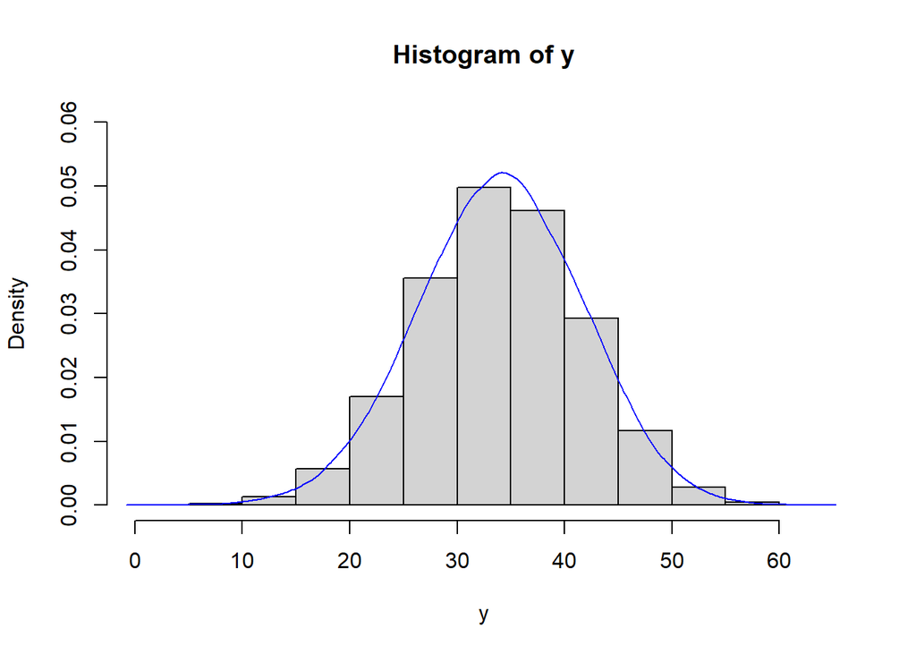

```r
> y <- 0
> for(i in 1:(10^5)){
+   b <- rbinom(10, size = 1, prob = 0.4)
+   n1 <- rnorm(10, mean = 1, sd = sqrt(2))
+   n2 <- rnorm(10, mean = 5, sd = sqrt(2))
+   x <- b * n1 + (1 - b) * n2
+   y[i] <- sum(x)
+ }
> mean(y)
[1] 34.00144
> var(y)
[1] 58.90565
> hist(y, probability = TRUE, ylim = c(0, 0.06))
> lines(density(y, bw = "SJ"), col = "blue")
```

При $n = 100$
$$Y = X_1 + X_2 + \ldots + X_{100}$$
$$E[X_1 + X_2 + \ldots + X_{100}] = 100 E[X_1] = 100 * 3.4 = 340$$
$$D[X_1 + X_2 + \ldots + X_{100}] = 100 D[X_1] = 100 * 5.842 = 584.2$$

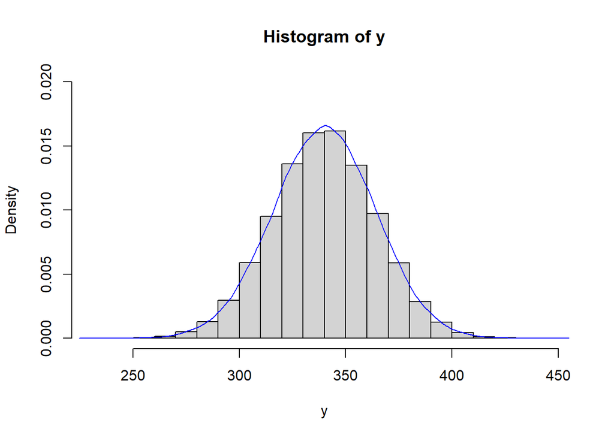

```r
> y <- 0
> for(i in 1:(10^5)){
+   b <- rbinom(100, size = 1, prob = 0.4)
+   n1 <- rnorm(100, mean = 1, sd = sqrt(2))
+   n2 <- rnorm(100, mean = 5, sd = sqrt(2))
+   x <- b * n1 + (1 - b) * n2
+   y[i] <- sum(x)
+ }
> mean(y)
[1] 339.8685
> var(y)
[1] 581.3205
> hist(y, probability = TRUE, ylim = c(0, 0.02))
> lines(density(y, bw = "SJ"), col = "blue")
```

т.к. $100$ е голямо можем да използваме централна гранична теорема (ЦГТ).

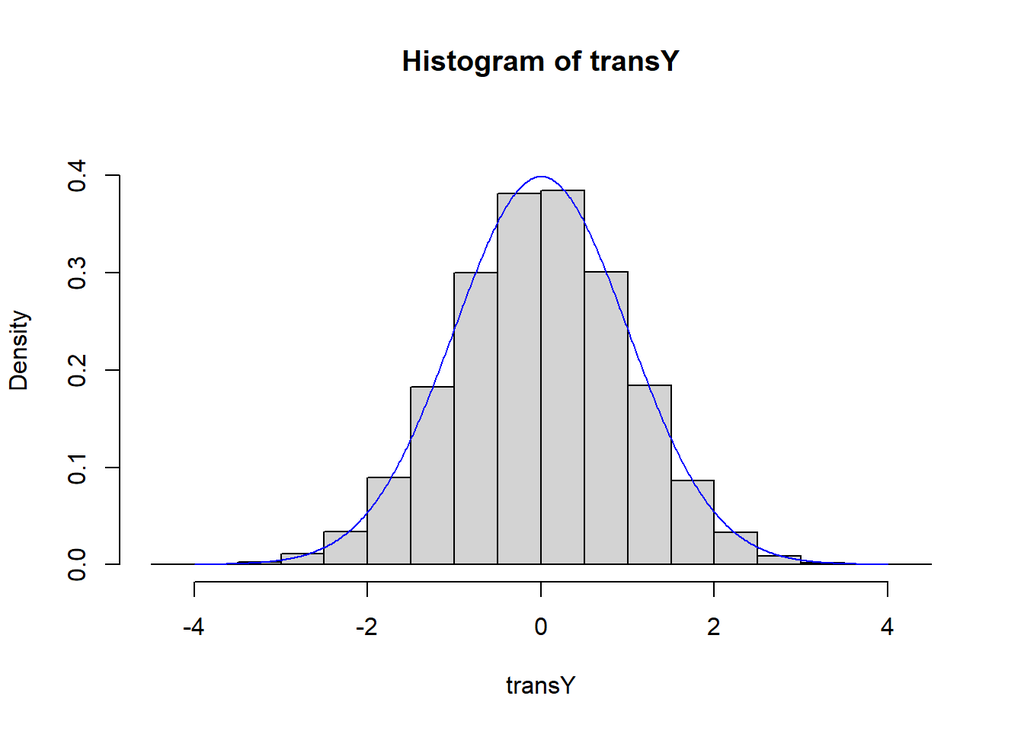

```r
> transY <- (y - 3.4 * n) / sqrt(5.842 * n)
> hist(transY, probability = TRUE, ylim = c(0, 0.44))
> xCoord <- seq(-4, 4, 0.01)
> lines(xCoord, dnorm(xCoord, 0, 1), col = "blue")
```

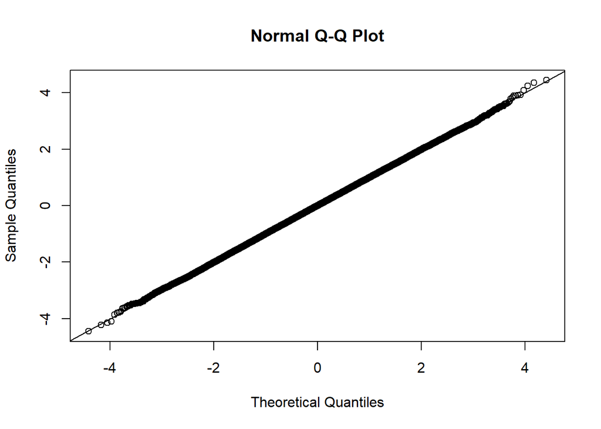

```r
> qqnorm(transY)
> qqline(transY)
```